# R Notebook

## 组间结果 - BECON、BECOV ——

### xTESTx - help understand the following function - do not run

```
    # 年度数据处理
    years <- output$cluster_ids %>%
      gsub(pattern = "\\(.*\\)", replacement = "") %>%
      gsub(pattern = "\\s+", replacement = "")
    BECON <- output$BECOS
    BECOV <- output$Coverages$between
```

### def function to extract BECONS for each solution terms

```r
extract_config_BECONS_by_year <- function(cluster_result) {
  # Get all configurations in the result
  config_list <- cluster_result$output
  result_list <- list()

  for (config_name in names(config_list)) {
    config_output <- config_list[[config_name]]

    # Extract year from cluster_ids, e.g., "2016 (31)" → "2016"
    years <- gsub(" \\(.*\\)", "", config_output$cluster_ids)

    # Extract BECOS values (same length as years)
    becos <- config_output$BECOS

    # Extract BECOV values
    becov <- config_output$Coverages$between


    # Build a data frame
    df <- data.frame(
      YEAR = years,
      CONFIG = config_name,
      BECONS = becos,
      BECOV = becov,
      stringsAsFactors = FALSE
    )

    result_list[[config_name]] <- df
  }

  # Combine all configurations
  final_df <- do.call(rbind, result_list)
  rownames(final_df) <- NULL
  return(final_df)
}
```

### extract BECONS for Y & ~Y cluster data

| YEAR | CONFIG | BECONS | BECOV | PATHWAY |
| --- | --- | --- | --- | --- |
| 2016 | X1*X3*X4*X5*X7*X8*X9 → Y | 0.9947669 | 0.4032097 | 1a |
| 2017 | X1*X3*X4*X5*X7*X8*X9 → Y | 0.9925750 | 0.5005169 | 1a |
| 2018 | X1*X3*X4*X5*X7*X8*X9 → Y | 0.9939383 | 0.5651395 | 1a |
| 2019 | X1*X3*X4*X5*X7*X8*X9 → Y | 0.9968867 | 0.5955821 | 1a |
| 2020 | X1*X3*X4*X5*X7*X8*X9 → Y | 1.0000000 | 0.4882051 | 1a |
| 2021 | X1*X3*X4*X5*X7*X8*X9 → Y | 0.9992880 | 0.5356801 | 1a |
| 2022 | X1*X3*X4*X5*X7*X8*X9 → Y | 0.9982954 | 0.5662285 | 1a |
| 2023 | X1*X3*X4*X5*X7*X8*X9 → Y | 0.9975425 | 0.2964099 | 1a |
| 2016 | X1*X4*X5*X6*X7*X8*X9 → Y | 0.9994546 | 0.2821995 | 1b |
| 2017 | X1*X4*X5*X6*X7*X8*X9 → Y | 1.0000000 | 0.3748351 | 1b |

[output cut: 22 more lines]

### visualization - BECON

#### cn

```r
# 绘图
library(ggplot2)
library(ggrepel)

# show CN text
library(showtext) #https://github.com/yixuan/showtext
showtext_auto(enable = TRUE)
# font_add("fangSong", regular = "./fonts/方正仿宋_GBK.TTF") # <<<<<<<<<<<<<<
# font_add("TimesNewRoman", regular = "./fonts/Times New Roman.ttf")
font_add("SongTi", regular = "./fonts/ STSongti-Regular-SC.ttf")# <<<<<<<<<<<<<<

# text repel data
label_data <- df_cluster_data_allY_BECONS_BECOV %>%
  group_by(PATHWAY) %>%
  filter(YEAR == max(YEAR)) %>%
  ungroup()


# store to pdf (create a pdf device) ---------------
# pdf(file = "./output_manual/组间一致性水平趋势图.pdf", width = 10, height = 8)
pdf(file = "./output/【Analysis_wk】3.充分性分析_组间一致性变化趋势图.pdf", width = 10, height = 8)

p_config_BECONS <- ggplot(df_cluster_data_allY_BECONS_BECOV,
                          aes(x = YEAR, y = BECONS, group = PATHWAY, color = PATHWAY)) +
  geom_line() +
  geom_point() +
  # geom_hline(yintercept = 0.90, linetype = "dashed", color = "black") +
  scale_x_discrete() +
  #scale_y_continuous(
  #  breaks = seq(0.0, 1.0, by = 0.1),
  #  limits = c(0.0, 1.0),
  #  expand = expansion(mult = c(0.01, 0.01))
  #) +
  labs(
    x = "年份",
    y = "组间一致性",
    color = "因果路径"
  ) +
  theme_bw(base_family = "SongTi") +
  theme(
    axis.title = element_text(family = "SongTi", size = 14),
    legend.title = element_text(family = "SongTi", size = 13),
    plot.margin = unit(c(1, 4, 1, 1), "cm"),
    legend.position = "bottom"
  ) +
  # guides(color = guide_legend(ncol = 1))  #+ # <<<<<<<< 每列 1 项，竖排
  # 添加标签：在最后一年（如 2023）右侧略微偏移
  geom_text_repel(
    family = "SongTi",
    data = label_data,
    aes(label = PATHWAY),
    nudge_x = 0.5,             # 向右偏移
    direction = "y",           # 避免上下重叠
    hjust = 0,                 # 左对齐
    segment.color = NA,        # 不显示连接线
    size = 3.0,
    box.padding = 0.3,
    point.padding = 0.05,
    #force = 0.6,              # 避让强度降低，避免推太远
    #force_pull = 0.3,         # 吸引力增强，靠近线尾
    max.overlaps = Inf,
    show.legend = FALSE        # 不用其出现在图例，
                               # 如果不告诉其如何显示图例，会在图例处每一个config前 加默认图例项 "a"
  )

print(p_config_BECONS)
dev.off()
```

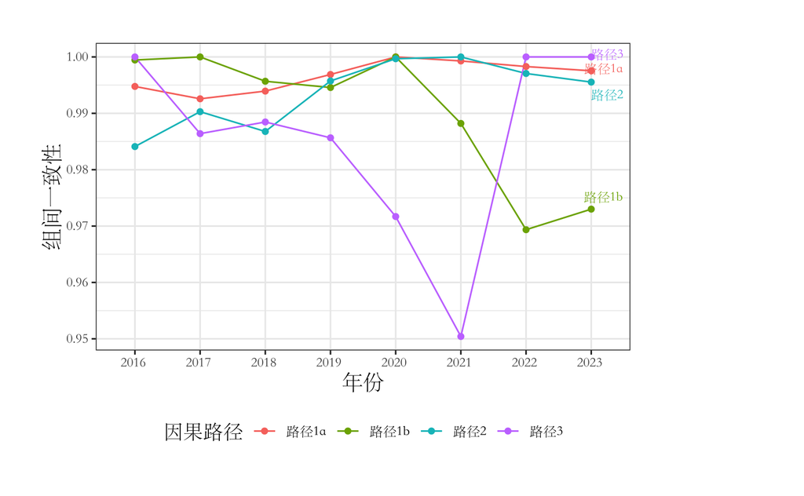

```r
p_config_BECONS
```

#### eng

```r
# 绘图
library(ggplot2)
library(ggrepel)

# show CN text
library(showtext) #https://github.com/yixuan/showtext
showtext_auto(enable = TRUE)

font_add(
  family = "Times_New_Roman",
  regular = "./fonts/Times New Roman.ttf",
  bold    = "./fonts/Times New Roman Bold.ttf"   # 添加 bold
)


# text repel data
label_data_eng <- df_cluster_data_allY_BECONS_BECOV_eng %>%
  group_by(PATHWAY) %>%
  filter(YEAR == max(YEAR)) %>%
  ungroup()


# store to pdf (create a pdf device) ---------------
# pdf(file = "./output_manual/组间一致性水平趋势图.pdf", width = 10, height = 8)
pdf(file = "./output/eng-【Analysis_wk】3.充分性分析_组间一致性变化趋势图.pdf", width = 10, height = 8)

p_config_BECONS_eng <- ggplot(df_cluster_data_allY_BECONS_BECOV_eng,
                              aes(x = YEAR, y = BECONS, group = PATHWAY, color = PATHWAY)) +
  geom_line() +
  geom_point() +
  # geom_hline(yintercept = 0.90, linetype = "dashed", color = "black") +
  scale_x_discrete() +
  #scale_y_continuous(
  #  breaks = seq(0.0, 1.0, by = 0.1),
  #  limits = c(0.0, 1.0),
  #  expand = expansion(mult = c(0.01, 0.01))
  #) +
  labs(
    x = "year",
    y = "BECONS",
    color = "Configuration Path"
  ) +
  theme_bw(base_family = "Times_New_Roman") +
  theme(
    axis.title = element_text(family = "Times_New_Roman", size = 14),
    legend.title = element_text(family = "Times_New_Roman", face   = "bold", size = 13), # 图例标题加粗
    plot.margin = unit(c(1, 4, 1, 1), "cm"),
    legend.position = "bottom"
  ) +
  # guides(color = guide_legend(ncol = 1))  #+ # <<<<<<<< 每列 1 项，竖排
  # 添加标签：在最后一年（如 2023）右侧略微偏移
  geom_text_repel(
    family = "Times_New_Roman",
    data = label_data_eng,
    aes(label = PATHWAY),
    nudge_x = 0.1,             # 向右偏移
    direction = "y",           # 避免上下重叠
    hjust = 0,                 # 左对齐
    segment.color = NA,        # 不显示连接线
    size = 3.0,
    box.padding = 0.3,
    point.padding = 0.05,
    #force = 0.6,              # 避让强度降低，避免推太远
    #force_pull = 0.3,         # 吸引力增强，靠近线尾
    max.overlaps = Inf,
    show.legend = FALSE        # 不用其出现在图例，
                               # 如果不告诉其如何显示图例，会在图例处每一个config前 加默认图例项 "a"
  )

print(p_config_BECONS_eng)
dev.off()
```

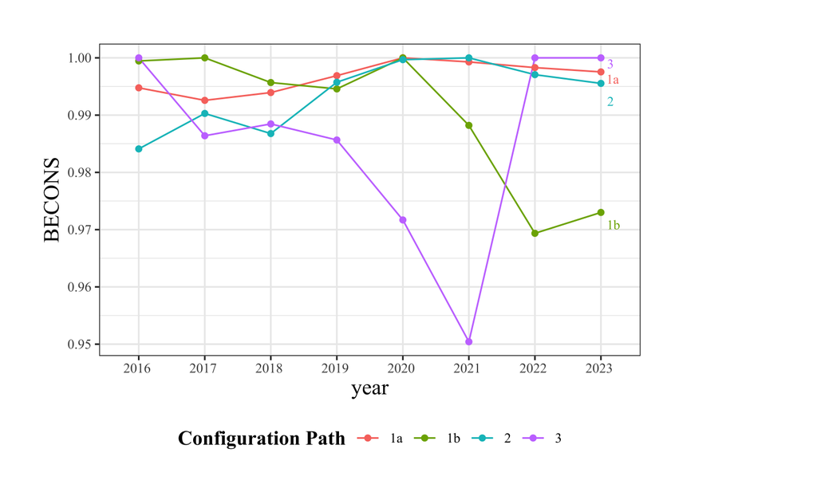

```r
p_config_BECONS_eng
```

### visualization - BECOV

#### cn

```r
# 绘图
library(ggplot2)
library(ggrepel)

# show CN text
library(showtext) #https://github.com/yixuan/showtext
showtext_auto(enable = TRUE)
# font_add("fangSong", regular = "./fonts/方正仿宋_GBK.TTF") # <<<<<<<<<<<<<<
# font_add("TimesNewRoman", regular = "./fonts/Times New Roman.ttf")
font_add("SongTi", regular = "./fonts/ STSongti-Regular-SC.ttf")# <<<<<<<<<<<<<<

# text repel data
label_data <- df_cluster_data_allY_BECONS_BECOV %>%
  group_by(PATHWAY) %>%
  filter(YEAR == max(YEAR)) %>%
  ungroup()


# store to pdf (create a pdf device) ---------------
# pdf(file = "./output_manual/组间一致性水平趋势图.pdf", width = 10, height = 8)
pdf(file = "./output/【Analysis_wk】3.充分性分析_组间覆盖度变化趋势图.pdf", width = 10, height = 8)

p_config_BECOV <- ggplot(df_cluster_data_allY_BECONS_BECOV,
                          aes(x = YEAR, y = BECOV, group = PATHWAY, color = PATHWAY)) +
  geom_line() +
  geom_point() +
  geom_hline(yintercept = 0.50, linetype = "dashed", color = "black", alpha = 0.4) +
  scale_x_discrete() +
  scale_y_continuous(
    breaks = seq(0.1, 0.8, by = 0.1),
    limits = c(0.1, 0.8)
    )+
  labs(
    x = "年份",
    y = "组间覆盖度",
    color = "因果路径"
  ) +
  theme_bw(base_family = "SongTi") +
  theme(
    axis.title = element_text(family = "SongTi", size = 14),
    legend.title = element_text(family = "SongTi", size = 13),
    plot.margin = unit(c(1, 4, 1, 1), "cm"),
    legend.position = "bottom"
  ) +
  #guides(color = guide_legend(ncol = 1))  #+ # <<<<<<<< 每列 1 项，竖排
  # 添加标签：在最后一年（如 2023）右侧略微偏移
  geom_text_repel(
    family = "SongTi",
    data = label_data,
    aes(label = PATHWAY),
    nudge_x = 0.5,             # 向右偏移
    direction = "both",        # 允许上下左右避让
    hjust = 0,                 # 左对齐
    segment.color = NA,        # 不显示连接线
    size = 3.0,
    box.padding = 0.3,
    point.padding = 0.05,
    force = 4,                # 排斥强度（更强避让）
    force_pull = 0.2,         # 吸引力增强，靠近线尾
    max.overlaps = Inf,
    show.legend = FALSE        # 不用其出现在图例，
                               # 如果不告诉其如何显示图例，会在图例处每一个config前 加默认图例项 "a"
  )


print(p_config_BECOV)
dev.off()
```

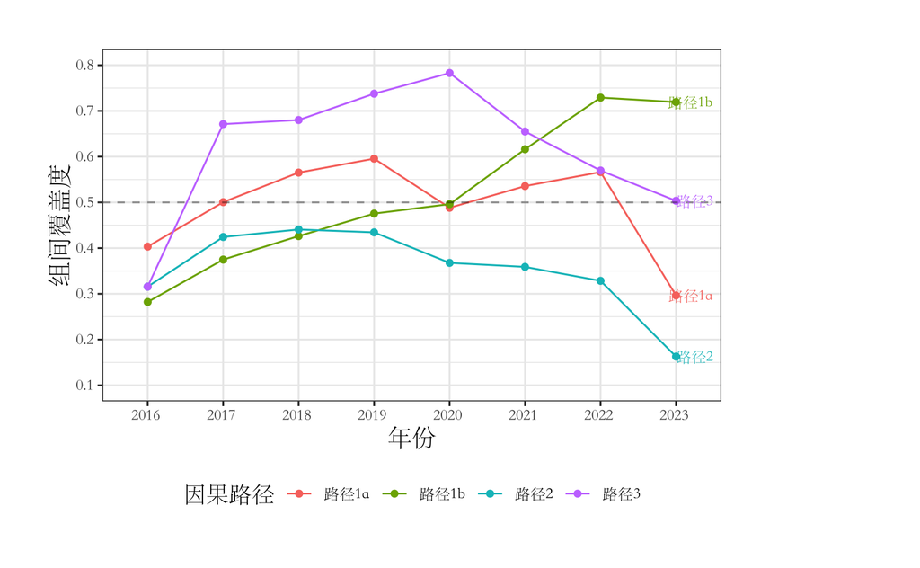

```r
p_config_BECOV
```

#### eng

```r
# 绘图
library(ggplot2)
library(ggrepel)

# show CN text
library(showtext) #https://github.com/yixuan/showtext
showtext_auto(enable = TRUE)

font_add(
  family = "Times_New_Roman",
  regular = "./fonts/Times New Roman.ttf",
  bold    = "./fonts/Times New Roman Bold.ttf"   # 添加 bold
)

# text repel data
label_data <- df_cluster_data_allY_BECONS_BECOV_eng %>%
  group_by(PATHWAY) %>%
  filter(YEAR == max(YEAR)) %>%
  ungroup()


# store to pdf (create a pdf device) ---------------
pdf(file = "./output/eng-【Analysis_wk】3.充分性分析_组间覆盖度变化趋势图.pdf", width = 10, height = 8)

p_config_BECOV_eng <- ggplot(df_cluster_data_allY_BECONS_BECOV_eng,
                             aes(x = YEAR, y = BECOV, group = PATHWAY, color = PATHWAY)) +
  geom_line() +
  geom_point() +
  geom_hline(yintercept = 0.50, linetype = "dashed", color = "black", alpha = 0.4) +
  scale_x_discrete() +
  scale_y_continuous(
    breaks = seq(0.1, 0.8, by = 0.1),
    limits = c(0.1, 0.8)
    )+
  labs(
    x = "year",
    y = "BECOV",
    color = "Configuration Path"
  ) +
  theme_bw(base_family = "Times_New_Roman") +
  theme(
    axis.title = element_text(family = "Times_New_Roman", size = 14),
    legend.title = element_text(family = "Times_New_Roman", face   = "bold", size = 13), # 图例标题加粗
    plot.margin = unit(c(1, 4, 1, 1), "cm"),
    legend.position = "bottom"
  ) +
  #guides(color = guide_legend(ncol = 1))  #+ # <<<<<<<< 每列 1 项，竖排
  # 添加标签：在最后一年（如 2023）右侧略微偏移
  geom_text_repel(
    family = "Times_New_Roman",
    data = label_data_eng,
    aes(label = PATHWAY),
    nudge_x = 0.1,             # 向右偏移
    direction = "both",        # 允许上下左右避让
    hjust = 0,                 # 左对齐
    segment.color = NA,        # 不显示连接线
    size = 3.0,
    box.padding = 0.3,
    point.padding = 0.05,
    force = 4,                # 排斥强度（更强避让）
    force_pull = 0.2,         # 吸引力增强，靠近线尾
    max.overlaps = Inf,
    show.legend = FALSE        # 不用其出现在图例，
                               # 如果不告诉其如何显示图例，会在图例处每一个config前 加默认图例项 "a"
  )


print(p_config_BECOV_eng)
dev.off()
```

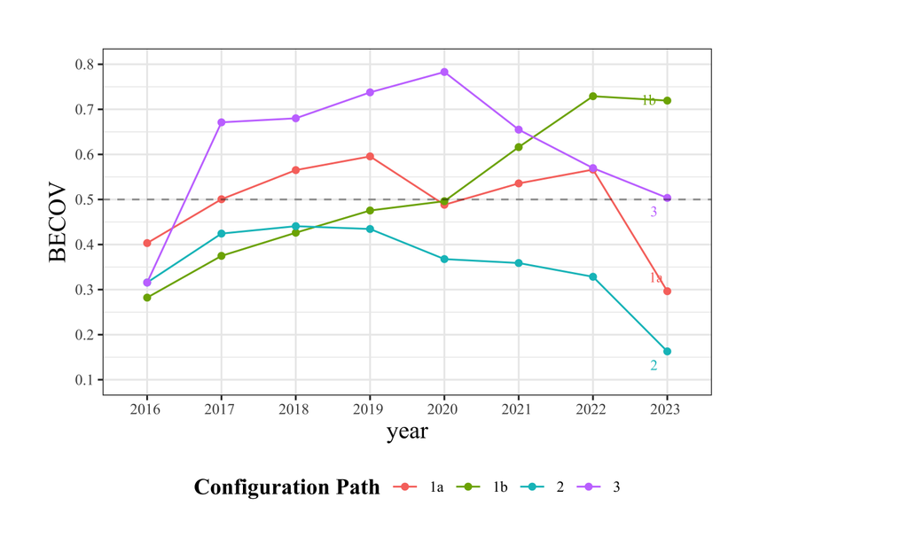

```r
p_config_BECOV_eng
```

### visualization - BECONS & BECOV - patch

#### cn

```r
library(showtext)
# 设置中文字体支持
showtext_auto(enable = TRUE)
# font_add("fangSong", regular = "./fonts/方正仿宋_GBK.TTF")
# font_add("TimesNewRoman", regular = "./fonts/Times New Roman.ttf")
font_add("SongTi", regular = "./fonts/ STSongti-Regular-SC.ttf")# <<<<<<<<<<<<<<



library(patchwork)

# 输出到 PDF 文件
 pdf(file = "./output/【Analysis_wk】组间一致性与覆盖度_趋势图_patch.pdf", width = 10, height = 8)

p_config_BECONS / p_config_BECOV +
  plot_layout(guides = "collect",
              heights = c(1,2)) &
  theme(legend.position = "bottom")


dev.off()
```

#### eng ★

```r
library(showtext)

showtext_auto(enable = TRUE)

font_add(
  family = "Times_New_Roman",
  regular = "./fonts/Times New Roman.ttf",
  bold    = "./fonts/Times New Roman Bold.ttf"   # 添加 bold
)


library(patchwork)

# 输出到 PDF 文件
 pdf(file = "./output/eng-【Analysis_wk】组间一致性与覆盖度_趋势图_patch★.pdf", width = 10, height = 8)

p_config_BECONS_eng / p_config_BECOV_eng +
  plot_layout(guides = "collect",
              heights = c(1,2)) &
  theme(legend.position = "bottom")


dev.off()
```

### visualization - BECONS & BECOV - same axis

```r
# 加载必要包
library(tidyverse)
library(ggrepel)
library(showtext)

# 设置中文字体支持
showtext_auto(enable = TRUE)
font_add("fangSong", regular = "./fonts/方正仿宋_GBK.TTF")
font_add("TimesNewRoman", regular = "./fonts/Times New Roman.ttf")

# 假设 df_cluster_data_allY_BECONS_BECOV 已存在，包含：
# YEAR: 年份
# CONFIG: 因果路径
# BECONS: 组间一致性
# BECOV: 组间覆盖度

# 1. 转换为长格式以绘制多个指标
df_long <- df_cluster_data_allY_BECONS_BECOV %>%
  pivot_longer(cols = c(BECONS, BECOV),
               names_to = "Metric",
               values_to = "Value") %>%
  mutate(Metric = dplyr::recode(Metric,
                                BECONS = "组间一致性",
                                BECOV = "组间覆盖度"
                                )
         )

# 2. 提取每个路径在每个指标最后一年用于标注
label_data <- df_long %>%
  group_by(CONFIG, Metric) %>%
  filter(YEAR == max(YEAR)) %>%
  ungroup()

# 3. 输出到 PDF 文件
pdf(file = "./output/【Analysis_wk】组间一致性与覆盖度_趋势图_含图注与标签.pdf", width = 10, height = 10)

# 4. 绘图
p_config_BECONS_BECOV <- ggplot(df_long, aes(x = YEAR, y = Value,
                         group = interaction(CONFIG, Metric))) +
  geom_line(aes(color = CONFIG, linetype = Metric), size = 0.5) +
  geom_point(aes(color = CONFIG), size = 1) +

  # 添加参考线
  geom_hline(yintercept = 0.90, linetype = "dashed", color = "black") +
  geom_hline(yintercept = 0.50, linetype = "dashed", color = "black") +

  # 添加尾部路径标签（两类指标）
  geom_text_repel(
    data = label_data,
    aes(label = CONFIG, y = Value, color = CONFIG),
    family = "TimesNewRoman",
    nudge_x = 2.8,
    direction = "y",
    hjust = 0,
    segment.color = NA,
    size = 3.0,
    box.padding = 0.3,
    point.padding = 0.05,
    max.overlaps = Inf,
    show.legend = FALSE
  ) +

  # 设置图例与轴标签
  labs(
    x = "年份",
    y = "指标值",
    color = "因果路径",
    linetype = "指标类型"
  ) +
  scale_x_discrete() +

  # y轴网格线
  scale_y_continuous(
  breaks = seq(0, 1, by = 0.1),     # 每 0.1 一个刻度
  limits = c(0, 1)#,                 # Y轴区间从 0 到 1
  #expand = c(0, 0)                  # 不额外留白（可选）
  )+

  theme_bw(base_family = "TimesNewRoman") +
  theme(
    text = element_text(family = "fangSong"),
    axis.title = element_text(family = "fangSong", size = 14),
    legend.title = element_text(family = "fangSong", size = 12),  # 图例标题
    legend.text = element_text(family = "fangSong", size = 10),   # 图例标签
    legend.position = "bottom",
    plot.margin = unit(c(1, 4, 1, 1), "cm")
  ) +
  guides(
    color = guide_legend(ncol = 1),
    linetype = guide_legend(ncol = 1)
    #linetype = guide_legend(override.aes = list(color = "black"))
  )
# 打印图表
print(p_config_BECONS_BECOV)
dev.off()
```

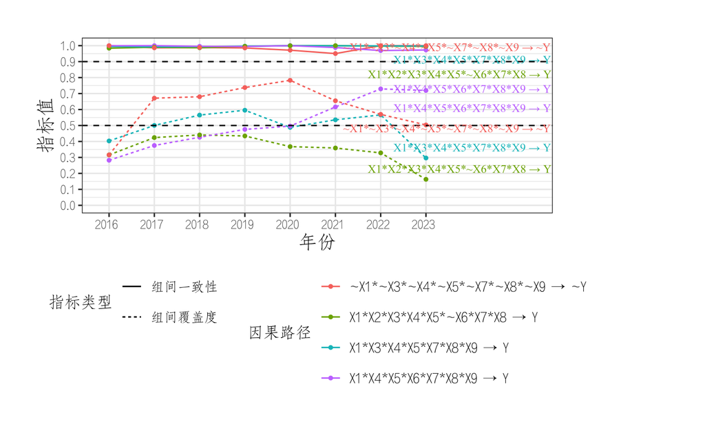

```r
# 可在 RStudio 中显示
p_config_BECONS_BECOV
```

## 组内结果 - WICON ——

### def function to extract WICONS for each solution terms

```r
extract_config_WICONS_by_year <- function(cluster_result) {
  # Get all configurations in the result
  config_list <- cluster_result$output
  result_list <- list()

  for (config_name in names(config_list)) {
    config_output <- config_list[[config_name]]

    # Extract year from cluster_ids, e.g., "湖北 (8) "  → "2016"
    provs <- gsub(pattern = "\\(.*\\)\\s+",
                  replacement = "",
                  x = config_output$unit_ids
                  ) %>%
      # 删去 空格
      gsub(pattern = "\\s",
           replacement = ""
           )

    # Extract WICON values (same length as provs)
    wicos <- config_output$WICONS


    # Build a data frame
    df <- data.frame(
      PROVS = provs,
      CONFIG = config_name,
      WICONS = wicos,
      stringsAsFactors = FALSE
    )

    result_list[[config_name]] <- df
  }

  # Combine all configurations
  final_df <- do.call(rbind, result_list)
  rownames(final_df) <- NULL
  return(final_df)
}
```

```r
# Y
df_cluster_data_Y_WICONS <- extract_config_WICONS_by_year(cluster_data_Y) %>%
  mutate(CONFIG = paste0(CONFIG," → Y"))

# print(df_cluster_data_Y_BECONS)


# ~Y
df_cluster_data_negY_WICONS <- extract_config_WICONS_by_year(cluster_data_negY) %>%
  mutate(CONFIG = paste0(CONFIG," → ~Y"))

# print(df_cluster_data_negY_BECONS)

# Y and ~Y
df_cluster_data_allY_WICONS <- rbind(df_cluster_data_Y_WICONS,
                                     df_cluster_data_negY_WICONS
                                     )

#print(df_cluster_data_allY_WICONS)


# 设定省份的固定顺序

prov_order <- c(
  "北京", "天津", "河北", "山西", "内蒙古", "辽宁", "吉林", "黑龙江",
  "上海", "江苏", "浙江", "安徽", "福建", "江西", "山东", "河南",
  "湖北", "湖南", "广东", "广西", "海南",
  "重庆", "四川", "贵州", "云南", "西藏",
  "陕西", "甘肃", "青海", "宁夏", "新疆"
)

# 把 PROVS 列转换factor

df_cluster_data_allY_WICONS$PROVS <- factor(df_cluster_data_allY_WICONS$PROVS,
                                            levels = prov_order
                                            )



# 按照固定省份顺序排序
df_cluster_data_allY_WICONS <- df_cluster_data_allY_WICONS %>%
  arrange(CONFIG, PROVS)

print(df_cluster_data_allY_WICONS)
```

[output not shown]

#### visualization - WICONS

```r
library(ggplot2)

# show CN text
library(showtext) #https://github.com/yixuan/showtext
showtext_auto(enable = TRUE)
font_add("fangSong", regular = "./fonts/方正仿宋_GBK.TTF") # <<<<<<<<<<<<<<
font_add("TimesNewRoman", regular = "./fonts/Times New Roman.ttf")


# store to pdf (create a pdf device) ---------------
# pdf(file = "./output_manual/组间一致性水平趋势图.pdf", width = 10, height = 8)
pdf(file = "./output/【Analysis_wk】3.充分性分析_组内一致性热力图.pdf", width = 16, height = 2.8)


p_config_WICONS <- ggplot(df_cluster_data_allY_WICONS, aes(x = PROVS, y = CONFIG, fill = WICONS)) +
  geom_tile(color = "white") +
  geom_text(aes(label = sprintf("%.2f", WICONS)),  # WICONS 保留2位
            size = 3,
            family = "TimesNewRoman") +  # <<< 用TimesNewRoman显示数值
  scale_fill_gradient2(
    #low = "#4575b4", mid = "#fcfdc4", high = "#d9352a", midpoint = 0.75,
    low = "#d9352a", mid = "#fcfdc4", high = "#4575b4", midpoint = 0.75,
    name = "组内一致性（WICONS）"
  ) +
  theme_minimal() +
  theme(
    axis.text.x = element_text(angle = 45, hjust = 1),
    panel.grid = element_blank(),
    text = element_text(family = "fangSong")  # 设置全局字体为仿宋
  ) +
  labs(x = "省份", y = "因果路径（CONFIG）", title = "各因果路径在不同省份的组内一致性热图")

print(p_config_WICONS)
dev.off()

p_config_WICONS
```

[output not shown]

## 个案追踪 (PIMS)

> Verweij S, Vis B. Three strategies to track configurations over time with Qualitative Comparative Analysis[J]. European Political Science Review, 2021, 13(1): 95-111.

> Figure 2, using again Portugal as an example, visualizes how the five cases-in-a-country map onto different ideal types over time. This also shows how a certain ideal type’s empirical presence varies over time, relative to that of the other ideal types. The figure can be easily constructed with Excel, by taking the fuzzy-set membership scores for the five cases in each of the four ideal types and then plotting them; it displays the `fuzzy-set membership scores` in different ways.

### 提取 PIMS

```r
# pims - prime implicant membership scores

df_PIMS_Y <- intsol_Y_esa$pims %>%
  rename_with(~ paste0(.x, "→Y")) %>%
  tibble::rownames_to_column(var = "CASE")

df_PIMS_negY <- intsol_negY_esa$pims %>%
  rename_with(~ paste0(.x, "→~Y")) %>%
  tibble::rownames_to_column(var = "CASE")

df_PIMS <- dplyr::full_join(x = df_PIMS_Y,
                            y = df_PIMS_negY,
                            by = "CASE"
                            )

# 看一眼
df_PIMS
```

[output not shown]

### def visualization - PIMS -patch - function

#### cn

```r
plot_PIMS_patch <- function(Region_Target) {

  # 加载包
  library(dplyr)
  library(tidyr)
  library(ggplot2)
  library(stringr)
  # devtools::install_github("ricardo-bion/ggradar")
  library(ggradar)
  library(scales)
  library(showtext)
  library(patchwork)

  # 设定地区名称（你只需要改这行）
  region_target <- Region_Target

  # 筛选该地区的所有案例（如 湖北_2016、湖北_2017）
  df_pims_region <- df_PIMS %>%
    filter(stringr::str_detect(CASE, region_target)) %>%
    mutate(YEAR = as.integer(stringr::str_extract(CASE, "\\d{4}")))  # 提取年份

  # 数据转换为长格式（路径做变量，方便 ggplot）
  df_pims_region_long <- df_pims_region %>%
    pivot_longer(cols = -c(CASE, YEAR),
                 names_to = "CONFIG",
                 values_to = "PIMS")

  df_pims_region_long <- df_pims_region_long %>%
    mutate(
      PATHWAY = case_when(
        CONFIG == "X1*X3*X4*X5*X7*X8*X9→Y" ~ "路径1a",
        CONFIG == "X1*X4*X5*X6*X7*X8*X9→Y" ~ "路径1b",
        CONFIG == "X1*X2*X3*X4*X5*~X6*X7*X8→Y" ~ "路径2",
        CONFIG == "~X1*~X3*~X4*~X5*~X7*~X8*~X9→~Y" ~ "路径3"
      )
    )


  # 绘图 ----

  # show CN text
  # library(showtext) #https://github.com/yixuan/showtext
  showtext_auto(enable = TRUE)
  font_add("SongTi", regular = "./fonts/ STSongti-Regular-SC.ttf")# <<<<<<<<<<<<<<

  # text repel data
  label_data <- df_pims_region_long %>%
    group_by(PATHWAY) %>%
    filter(YEAR == max(YEAR)) %>%
    ungroup()


  ## plot line -----

  # 绘图：路径随时间变化图（每条路径一条线） ----

  p_case_pims <-
    ggplot(df_pims_region_long, aes(x = YEAR, y = PIMS, color = PATHWAY)) +
    geom_line() +
    geom_point() +
    geom_hline(yintercept = 0.5,
               linetype = "dashed",
               color = "gray50") +
    scale_y_continuous(limits = c(0, 1)) +
    scale_x_continuous(breaks = sort(unique(df_pims_region_long$YEAR))) +
    labs(
      title = paste0("路径隶属度演化", "（", region_target, "）"),
      #subtitle = "每条线代表一个路径组态的 fuzzy membership 值",
      x = "年份",
      y = "模糊集隶属度得分",
      color = "因果路径"
    ) +

    theme_bw(base_family = "SongTi") +
    theme(
      text = element_text(family = "SongTi"),
      plot.title = element_text(family = "SongTi", size = 18),
      axis.title = element_text(family = "SongTi", size = 14),
      legend.title = element_text(family = "SongTi", size = 12),
      # 图例标题
      legend.text = element_text(family = "SongTi", size = 12),# <<<<<<<<<<<<<<<<
      axis.text.x = element_text(size = 12, face = "bold", family = "SongTi"),  # x轴：年份# <<<<<<<<<<<<<<<<
      axis.text.y = element_text(size = 12, face = "bold", family = "SongTi"),  # y轴：数值# <<<<<<<<<<<<<<<<
      # 图例标签
      legend.position = "bottom",
      plot.margin = unit(c(1, 4, 1, 1), "cm")
    ) +
    # guides(
    #   color = guide_legend(ncol = 1)
    #   #linetype = guide_legend(ncol = 1)
    #   #linetype = guide_legend(override.aes = list(color = "black"))
    # )
    # 添加标签：在最后一年（如 2023）右侧略微偏移
    geom_text_repel(
      family = "SongTi",
      data = label_data,
      aes(label = PATHWAY),
      nudge_x = 0.5,
      # 向右偏移
      direction = "both",
      # 允许上下左右避让
      hjust = 0,
      # 左对齐
      segment.color = NA,
      # 不显示连接线
      size = 4.0, # <<<<<<<<<<<<<<<<
      box.padding = 0.3,
      point.padding = 0.05,
      force = 4,
      # 排斥强度（更强避让）
      force_pull = 0.2,
      # 吸引力增强，靠近线尾
      max.overlaps = Inf,
      show.legend = FALSE        # 不用其出现在图例，
      # 如果不告诉其如何显示图例，会在图例处每一个config前 加默认图例项 "a"
    )

  ## plot radar -----

  df_radar <- df_pims_region_long %>%
    group_by(PATHWAY, YEAR) %>%
    summarise(PIMS = mean(PIMS, na.rm = TRUE), .groups = "drop") %>%
    pivot_wider(names_from = YEAR, values_from = PIMS)

  df_radar[is.na(df_radar)] <- 0  # 可选处理缺失值

  # 绘图
  p_case_pims_radar <- ggradar(
    df_radar,

    font.radar = "SongTi",

    # The labels of the grid
    values.radar = c("0", "0.5", "1"),
    grid.min = 0,
    grid.mid = 0.5,
    grid.max = 1,
    group.line.width = 0.5,
    group.point.size = 2,
    axis.label.size = 5,


    background.circle.colour = "white",
    axis.line.colour = "gray60",
    gridline.min.colour = "gray60",
    gridline.mid.colour = "gray60",
    gridline.max.colour = "gray60",
    group.colours = c("#f8766d", "#7cae00", "#00bfc4", "#c77cff"),

    legend.position = "bottom",
    legend.text.size = 10,

    fill = TRUE,
    fill.alpha = 0.75,

    #plot.title = paste0("路径隶属度演化（", region_target, "）")
  ) +
    labs(title = paste0("路径隶属度演化（", region_target, "）")) +
    #theme_bw(base_family = "TimesNewRoman") +
    theme(
      text = element_text(family = "SongTi"),
      axis.title = element_text(family = "SongTi", size = 14),
      legend.title = element_text(family = "SongTi", size = 12),
      # 图例标题
      legend.text = element_text(family = "SongTi", size = 10),
      # 图例标签
      legend.position = "none", # 不显示 legend
      plot.title = element_blank() # 不显示 plot title
    )

  # patch -----

  # library(patchwork)

  # 移除 plot.margin
  # p1 <- p_case_pims + theme(plot.margin = unit(c(0, 0, 0, 0), "cm"))
  # p2 <- p_case_pims_radar + theme(plot.margin = unit(c(0, 0, 0, 0), "cm"))
  p1 <- p_case_pims +
    theme(
      plot.margin = unit(c(0, 0, 0, 0), "cm"),
      plot.tag = element_text(
        size = 20,
        face = "bold",
        family = "SongTi"
      )
    ) +
    labs(tag = "A")

  p2 <- p_case_pims_radar +
    theme(
      plot.margin = unit(c(0, 0, 0, 0), "cm"),
      plot.tag = element_text(
        size = 20,
        face = "bold",
        family = "SongTi"
      )
    ) +
    labs(tag = "B")



  # 输出到 PDF 文件

  pdf(file = paste0("./output/【Analysis_wk】3.充分性分析_路径模糊集隶属度_patch（",
                    region_target,
                    "）.pdf"),
      width = 14.5,
      height = 7)

  print(
    (p1 | p2) +
    plot_layout(ncol = 2,
                widths = c(1, 1),
                guides = "keep") &
      theme(legend.position = "bottom")
  )



  # print(
  #   (p1 | p2) +
  #     plot_layout(ncol = 2, widths = c(1, 1), guides = "keep") +
  #     plot_annotation(
  #       tag_levels = "A",
  #       theme = theme(
  #         legend.position = "bottom",
  #         plot.title = element_text(size = 16, face = "bold", family = "SongTi"),
  #         plot.tag = element_text(size = 16, face = "bold", family = "SongTi")
  #         )
  #       )
  #   )

  dev.off()


}
```

#### eng

```r
# plot title to eng
region_map2eng <- c(
  "北京" = "Beijing",
  "天津" = "Tianjin",
  "河北" = "Hebei",
  "山西" = "Shanxi",
  "内蒙古" = "Inner Mongolia",
  "辽宁" = "Liaoning",
  "吉林" = "Jilin",
  "黑龙江" = "Heilongjiang",
  "上海" = "Shanghai",
  "江苏" = "Jiangsu",
  "浙江" = "Zhejiang",
  "安徽" = "Anhui",
  "福建" = "Fujian",
  "江西" = "Jiangxi",
  "山东" = "Shandong",
  "河南" = "Henan",
  "湖北" = "Hubei",
  "湖南" = "Hunan",
  "广东" = "Guangdong",
  "广西" = "Guangxi",
  "海南" = "Hainan",
  "重庆" = "Chongqing",
  "四川" = "Sichuan",
  "贵州" = "Guizhou",
  "云南" = "Yunnan",
  "西藏" = "Tibet",
  "陕西" = "Shaanxi",
  "甘肃" = "Gansu",
  "青海" = "Qinghai",
  "宁夏" = "Ningxia",
  "新疆" = "Xinjiang"
)

pathway_colors <- c(
  "1a" = "#f8766d",
  "1b" = "#7cae00",
  "2"  = "#00bfc4",
  "3"  = "#c77cff"
)


plot_PIMS_patch <- function(Region_Target) {

  # 加载包
  library(dplyr)
  library(tidyr)
  library(ggplot2)
  library(stringr)
  # devtools::install_github("ricardo-bion/ggradar")
  library(ggradar)
  library(scales)
  library(showtext)
  library(patchwork)

  # 设定地区名称（你只需要改这行）
  region_target <- Region_Target

  # 筛选该地区的所有案例（如 湖北_2016、湖北_2017）
  df_pims_region <- df_PIMS %>%
    filter(stringr::str_detect(CASE, region_target)) %>%
    mutate(YEAR = as.integer(stringr::str_extract(CASE, "\\d{4}")))  # 提取年份

  # 数据转换为长格式（路径做变量，方便 ggplot）
  df_pims_region_long <- df_pims_region %>%
    pivot_longer(cols = -c(CASE, YEAR),
                 names_to = "CONFIG",
                 values_to = "PIMS")

  df_pims_region_long <- df_pims_region_long %>%
    mutate(
      PATHWAY = case_when(
        CONFIG == "X1*X3*X4*X5*X7*X8*X9→Y" ~ "1a",
        CONFIG == "X1*X4*X5*X6*X7*X8*X9→Y" ~ "1b",
        CONFIG == "X1*X2*X3*X4*X5*~X6*X7*X8→Y" ~ "2",
        CONFIG == "~X1*~X3*~X4*~X5*~X7*~X8*~X9→~Y" ~ "3"
      )
    )


  # 绘图 ----


  # library(showtext) #https://github.com/yixuan/showtext
  showtext_auto(enable = TRUE)

  font_add(
    family = "Times_New_Roman",
    regular = "./fonts/Times New Roman.ttf",
    bold    = "./fonts/Times New Roman Bold.ttf"   # 添加 bold
    )

  # text repel data
  label_data <- df_pims_region_long %>%
    group_by(PATHWAY) %>%
    filter(YEAR == max(YEAR)) %>%
    ungroup()


  ## plot line -----

  # 绘图：路径随时间变化图（每条路径一条线） ----

  p_case_pims <-
    ggplot(df_pims_region_long, aes(x = YEAR, y = PIMS, color = PATHWAY)) +
    geom_line() +
    geom_point() +
    scale_color_manual(values = pathway_colors) + # <<<<<<<<<<<<<<<
    geom_hline(yintercept = 0.5,
               linetype = "dashed",
               color = "gray50") +
    scale_y_continuous(limits = c(0, 1)) +
    scale_x_continuous(breaks = sort(unique(df_pims_region_long$YEAR))) +
    labs(
      # title = paste0("Evolution of Configuration Path Membership in ", region_target, " (2016–2023)"),
      # Evolution of Configurational Path Membership in Beijing (2016–2023)

      #subtitle = "每条线代表一个路径组态的 fuzzy membership 值",
      x = "year",
      y = "fuzzy-set membership scores",
      color = "Configuration Path"
    ) +

    theme_bw(base_family = "Times_New_Roman") +
    theme(
      text = element_text(family = "SongTi"),
      plot.title = element_text(family = "Times_New_Roman",
                                face   = "bold",      # 标题加粗
                                hjust  = 0.5          # 标题居中
                                ),
      axis.title = element_text(family = "Times_New_Roman", size = 14),
      axis.text = element_text(family = "Times_New_Roman"),
      legend.title = element_text(family = "Times_New_Roman", face = "bold", size = 12), # 图例标题加粗

      legend.position = "bottom",
      plot.margin = unit(c(1, 4, 1, 1), "cm")
    ) +
    # guides(
    #   color = guide_legend(ncol = 1)
    #   #linetype = guide_legend(ncol = 1)
    #   #linetype = guide_legend(override.aes = list(color = "black"))
    # )
    # 添加标签：在最后一年（如 2023）右侧略微偏移
    geom_text_repel(
      family = "SongTi",
      data = label_data,
      aes(label = PATHWAY),
      nudge_x = 0.5,
      # 向右偏移
      direction = "both",
      # 允许上下左右避让
      hjust = 0,
      # 左对齐
      segment.color = NA,
      # 不显示连接线
      size = 4.0, # <<<<<<<<<<<<<<<<
      box.padding = 0.3,
      point.padding = 0.05,
      force = 4,
      # 排斥强度（更强避让）
      force_pull = 0.2,
      # 吸引力增强，靠近线尾
      max.overlaps = Inf,
      show.legend = FALSE        # 不用其出现在图例，
      # 如果不告诉其如何显示图例，会在图例处每一个config前 加默认图例项 "a"
    )

  ## plot radar -----

  df_radar <- df_pims_region_long %>%
    group_by(PATHWAY, YEAR) %>%
    summarise(PIMS = mean(PIMS, na.rm = TRUE), .groups = "drop") %>%
    pivot_wider(names_from = YEAR, values_from = PIMS)

  df_radar[is.na(df_radar)] <- 0  # 可选处理缺失值

  # 绘图
  p_case_pims_radar <- ggradar(
    df_radar,

    font.radar = "SongTi",

    # The labels of the grid
    values.radar = c("0", "0.5", "1"),
    grid.min = 0,
    grid.mid = 0.5,
    grid.max = 1,
    group.line.width = 0.5,
    group.point.size = 2,
    axis.label.size = 5,


    background.circle.colour = "white",
    axis.line.colour = "gray60",
    gridline.min.colour = "gray60",
    gridline.mid.colour = "gray60",
    gridline.max.colour = "gray60",
    group.colours = pathway_colors, # <<<<<<<<<<<<

    legend.position = "bottom",
    legend.text.size = 10,

    fill = TRUE,# <<<<<<<<<<<<
    fill.alpha = 0.075,

    #plot.title = paste0("路径隶属度演化（", region_target, "）")
  ) +
    #labs(title = paste0("路径隶属度演化（", region_target, "）")) +
    # theme_bw(base_family = "TimesNewRoman") +
    theme(
      text = element_text(family = "TimesNewRoman"),
      axis.title = element_text(family = "TimesNewRoman", size = 14),
      legend.title = element_text(family = "TimesNewRoman", size = 12),
      # 图例标题
      legend.text = element_text(family = "TimesNewRoman", size = 10),
      # 图例标签
      legend.position = "none", # 不显示 legend
      plot.title = element_blank() # 不显示 plot title
    )


  # patch -----

  # library(patchwork)

  # 移除 plot.margin
  # p1 <- p_case_pims + theme(plot.margin = unit(c(0, 0, 0, 0), "cm"))
  # p2 <- p_case_pims_radar + theme(plot.margin = unit(c(0, 0, 0, 0), "cm"))
  p1 <- p_case_pims +
    theme(
      plot.margin = unit(c(0, 0, 0, 0), "cm"),
      plot.tag = element_text(
        size = 20,
        face = "bold",
        family = "TimesNewRoman"
      )
    ) +
    labs(tag = "A")

  p2 <- p_case_pims_radar +
    theme(
      plot.margin = unit(c(0, 0, 0, 0), "cm"),
      plot.tag = element_text(
        size = 20,
        face = "bold",
        family = "TimesNewRoman"
      )
    ) +
    labs(tag = "B")



  # 输出到 PDF 文件

  pdf(file = paste0("./output/eng-【Analysis_wk】3.充分性分析_路径模糊集隶属度_patch（",
                    region_target,
                    "）.pdf"),
      width = 14.5,
      height = 7)

  # print(
  #   (p1 | p2) +
  #   plot_layout(ncol = 2,
  #               widths = c(1, 1)
  #               )&
  #     theme(legend.position = "bottom")
  # )

  print(
    (p1 | p2) +
      plot_layout(ncol = 2,
                  widths = c(1, 1)
                  ) +
      plot_annotation(
        title = paste0(
          "Evolution of Configuration Path Membership in ",
          region_map2eng[region_target], # 中文转英文名称
          " (2016–2023)"
          ),
      theme = theme(
        plot.title = element_text(
          hjust = 0.5,          # 居中
          size = 18,
          face = "bold",
          family = "Times_New_Roman",
          margin = margin(b = 15) # 标题和下面的图之间留15个pt的间距
        )
      )
    ) &
      theme(legend.position = "bottom")
  )


  # print(
  #   (p1 | p2) +
  #     plot_layout(ncol = 2, widths = c(1, 1), guides = "keep") +
  #     plot_annotation(
  #       tag_levels = "A",
  #       theme = theme(
  #         legend.position = "bottom",
  #         plot.title = element_text(size = 16, face = "bold", family = "SongTi"),
  #         plot.tag = element_text(size = 16, face = "bold", family = "SongTi")
  #         )
  #       )
  #   )

  dev.off()


} # end of function
```

```r
plot_PIMS_patch(Region_Target = "安徽")
```

### def - regions and plot

```r
regions_to_plot <- c(
  "北京", "天津", "河北", "山西", "内蒙古", "辽宁", "吉林", "黑龙江",
  "上海", "江苏", "浙江", "安徽", "福建", "江西", "山东", "河南",
  "湖北", "湖南", "广东", "广西", "海南",
  "重庆", "四川", "贵州", "云南", "西藏",
  "陕西", "甘肃", "青海", "宁夏", "新疆"
)

plot_PIMS_patch_batch(regions_to_plot)
```

```
[1] "plotting：北京"
[1] "plotting：天津"
[1] "plotting：河北"
[1] "plotting：山西"
[1] "plotting：内蒙古"
[1] "plotting：辽宁"
[1] "plotting：吉林"
[1] "plotting：黑龙江"
[1] "plotting：上海"
[1] "plotting：江苏"
[1] "plotting：浙江"
[1] "plotting：安徽"
[1] "plotting：福建"
[1] "plotting：江西"
[1] "plotting：山东"
```

[output cut: 16 more lines]

# 稳健性检验 by adjust n、incl、PRI cut —–

## 创建目录 ./output/robustness 如果不存在

```r
dir_path_robust <- "./output/robustness"
if (!dir.exists(dir_path_robust)) {
  dir.create(dir_path_robust, recursive = TRUE)
}
```

## def get_intsol_Y_res_Final

```r
# val.incl.cut <- 0.75
# val.n.cut <- 2
# val.pri.cut <- 0.6

get_intsol_Y_res_Final <- function(val.incl.cut, val.n.cut, val.pri.cut){
    tt_Y <- QCA::truthTable(data = df.Fuzzy.case,
                          outcome = "Y",
                          conditions = conditions,
                          incl.cut = val.incl.cut, n.cut = val.n.cut, pri.cut = val.pri.cut,
                          show.cases = TRUE,
                          sort.by = "OUT"
                          )

  tt_Y



  ### 寻找必要的组合 - Necessary Disjunctions of SUIN Conditions




  sp_Y <- QCA::superSubset(data = df.Fuzzy.case,
                           outcome = "Y",
                           conditions = conditions %>% paste(collapse = ","),  # "X1,X2,X3,X4,X5,X6..."
                           incl.cut = 0.90,
                           cov.cut = 0.5, #<-----
                           ron.cut = 0.5 #<-----
                           )
  sp_Y

  config.SUIN_cond <- sp_Y$coms %>% colnames()
  config.SUIN_cond



  ### find CSA - contradictory simplifying assumptions


  # get row CSA ----
  row.CSA <- QCA::findRows(obj = tt_Y, type = 2)  # contradictory simplifying assumptions
  row.CSA

  # get config CSA ----

  # 一致性异常的案例 Deviant cases for consistency (DCC)

  tt_Y_dcc <-  QCA::truthTable(data = df.Fuzzy.case,
                               outcome = "Y",
                               conditions = conditions %>% paste(collapse = ","),
                               incl.cut = 0.75, n.cut = 2, pri.cut = 0.6,
                               show.cases = TRUE,
                               # sort.by = "OUT", # 不能sort by OUT 因为后面slice是按行号进行的
                               complete = TRUE,
                               dcc = TRUE)


  # get untenable_LR config from truthTable
  tt_Y_CSA <- tt_Y_dcc$tt %>%
    slice(row.CSA) %>%
    select(conditions) # select(X1,X2,X3,......)

  tt_Y_CSA

  # def function
  convert_to_config <- function(row) {
    names <- colnames(tt_Y_CSA)  # 获取列名 #  "X1" "X2" "X3" "X4" "X5" "X6" "X7" "X8" "X9"
    terms <- ifelse(row == 1, names, paste0("~", names))  # 1: 直接列名, 0: 加上 ~
    paste(terms, collapse = "*")  # 用 "*" 连接所有变量
  }

  # end def function----


  # 对数据框的每一行进行转换，并存入向量

  # X1 X2 X3 X4 X5 X6 X7 X8 X9
  # 116  0  0  1  1  1  0  0  1  1
  # ↓
  #                              116
  # "~X1*~X2*X3*X4*X5*~X6*~X7*X8*X9"

  # 应用函数到 tt_Y_CSA 每一行

  config.CSA <- apply(tt_Y_CSA, 1, convert_to_config)
  config.CSA



  ### TruthTable - esa - rm untenable


  tt_Y_esa <- SetMethods::esa(oldtt = tt_Y,
                              nec_cond = config.SUIN_cond,
                              untenable_LR = config.CSA
                              )
  tt_Y_esa




  ### 复杂解 Complex Solution ----


  compsol_Y_esa <- QCA::minimize(input = tt_Y_esa,
                                 details = TRUE,
                                 row.dom = TRUE # to avoid model ambiguity
                                 )

  compsol_Y_esa





  ### 简单解 Parsimonious Solution ----


  parsol_Y_esa <- QCA::minimize(input = tt_Y_esa,
                                include = "?", # include LR
                                details = TRUE,
                                row.dom = TRUE # to avoid model ambiguity - else up to 18+ Model in the result
                                )

  parsol_Y_esa


  ### 中间解 Intermediate Solution ----



  intsol_Y_esa <- QCA::minimize(input = tt_Y_esa,
                                details = TRUE,
                                row.dom = TRUE # to avoid model ambiguity
                                )

  intsol_Y_esa




  ### 组间一致性调整距离、组内一致性调整距离

  #### sol = 1（intsol 也只有一个model）

  ##### caculate cluster

  cluster_data_Y <- SetMethods::cluster(data = df.Fuzzy.case,
                                        results = intsol_Y_esa,
                                        outcome="Y",
                                        unit_id = "ID", cluster_id = "YEAR",
                                        sol = 1, # <---- 1 st solution (M1)
                                        wicons = TRUE
                                        )

  cluster_data_Y


  ##### caculate solution adjusted distance



  SolutionTerm_names <- names(cluster_data_Y$output)

  # distance between pooled (Between Consistency Distance, BECON distance)
  BECONS_distance <- sapply(SolutionTerm_names,
                            function(solTerm) {
                              cluster_data_Y$output[[solTerm]]$dBP
                              }
                            )

  # distance within pooled (Within Consistency Distance, WICON distance)
  WICONS_distance <- sapply(SolutionTerm_names,
                            function(solTerm) {
                              cluster_data_Y$output[[solTerm]]$dWP
                              }
                            )

  # `Castro R G, Ariño M A. A general approach to panel data set-theoretic research[J]. Journal of Advances in Management Sciences & Information Systems, 2016, 2: 63-76.`
  # $$
  # \text{BECONS adjusted distance} = \frac{\text{BECONS distance}}{\sqrt{\frac{n}{n^2 + 3n + 2}}}
  # \text{WICONS adjusted distance} = \frac{\text{WICONS distance}}{\sqrt{\frac{n}{n^2 + 3n + 2}}}
  # $$
  #  n is equal to the number of elements in the vector

  # n.t.vec <- df.Fuzzy$YEAR %>% unique() %>% length()
  # n.N.vec <- df.Fuzzy$ID %>% unique() %>% length()

  # calculate BECONS_adjusted_distance
  BECONS_adjusted_distance = BECONS_distance/sqrt(n.t.vec / (n.t.vec^2 + 3 * n.t.vec + 2))

  # caluculate WICONS_adjusted_distance
  WICONS_adjusted_distance = WICONS_distance/sqrt(n.N.vec / (n.N.vec^2 + 3 * n.N.vec + 2))

  df.sol.adj.distance <- tibble(config = SolutionTerm_names,
                                BECONS_adjusted_distance = BECONS_adjusted_distance,
                                WICONS_adjusted_distance = WICONS_adjusted_distance
                                )
  df.sol.adj.distance


  ### 整理结果



  # 从intsol_Y_esa提取结果
  intsol_Y_res_Overall <- intsol_Y_esa$IC$sol.incl.cov

  intsol_Y_res_SolutionTerm <-  intsol_Y_esa$IC$incl.cov
  rownames(intsol_Y_res_Overall) <- "Overall"

  # 添加 config 列
  intsol_Y_res_Overall$config <- "Overall"
  intsol_Y_res_SolutionTerm$config <- rownames(intsol_Y_res_SolutionTerm)

  # 补齐缺失列（covU 和 cases）到 Overall 表
  intsol_Y_res_Overall$covU <- NA
  intsol_Y_res_Overall$cases <- NA



  # 确保两张表列顺序一致，并把config列排到最左边
  intsol_Y_res_Overall <- intsol_Y_res_Overall[, c("config", "inclS", "PRI", "covS", "covU", "cases")]
  intsol_Y_res_SolutionTerm <- intsol_Y_res_SolutionTerm[, c("config", "inclS", "PRI", "covS", "covU", "cases")]

  # 合并两张表
  intsol_Y_res_Combined <- rbind(intsol_Y_res_SolutionTerm, intsol_Y_res_Overall)

  # 移除行名
  rownames(intsol_Y_res_Combined) <- NULL

  # 查看合并后的结果
  # print(intsol_Y_res_Combined)


  # 合并 intsol_Y_res_Combined 和 df.sol.adj.distance
  intsol_Y_res_Final <- intsol_Y_res_Combined %>%
    left_join(df.sol.adj.distance, by = "config")


  # 调整列顺序：将 cases 放到最后
  intsol_Y_res_Final <- intsol_Y_res_Final %>%
    select(-cases, everything(), cases)


  writexl::write_xlsx(x = intsol_Y_res_Final,
                      path = paste0("./output/robustness/【Analysis_wk】3.充分条件分析_结果_Y",
                                    "_incl.cut = ", val.incl.cut,
                                    "_n.cut = ", val.n.cut,
                                    "_pri.cut =", val.pri.cut,
                                    ".xlsx"
                                    )

                      )


  #print(intsol_Y_res_Final)


} # end def funciton get_intsol_Y_res_Final
```

## def get_intsol_negY_res_Final

```r
get_intsol_negY_res_Final <- function(val.incl.cut, val.n.cut, val.pri.cut){
  ### 构建真值表 ----

  tt_negY <- QCA::truthTable(data = df.Fuzzy.case,
                             outcome = "~Y",
                             conditions = conditions,
                             incl.cut = val.incl.cut, n.cut = val.n.cut, pri.cut = val.pri.cut,
                             show.cases = TRUE,
                             sort.by = "OUT"
                             )

  tt_negY

  ### 寻找必要的组合 - Necessary Disjunctions of SUIN Conditions




  sp_negY <- QCA::superSubset(data = df.Fuzzy.case,
                           outcome = "~Y",
                           conditions = conditions %>% paste(collapse = ","),  # "X1,X2,X3,X4,X5,X6..."
                           incl.cut = 0.90,
                           cov.cut = 0.5, #<-----
                           ron.cut = 0.5 #<-----
                           )
  sp_negY

  config.SUIN_cond.negY <- sp_negY$coms %>% colnames()
  config.SUIN_cond.negY

  ### find CSA - contradictory simplifying assumptions

  # get row CSA ----
  row.CSA.negY <- QCA::findRows(obj = tt_negY, type = 2)  # contradictory simplifying assumptions
  row.CSA.negY

  # get config CSA ----

  # 一致性异常的案例 Deviant cases for consistency (DCC)

  tt_negY_dcc <-  QCA::truthTable(data = df.Fuzzy.case,
                                  outcome = "~Y",
                                  conditions = conditions %>% paste(collapse = ","),
                                  incl.cut = 0.75, n.cut = 2, pri.cut = 0.6,
                                  show.cases = TRUE,
                                  # sort.by = "OUT", # 不能sort by OUT 因为后面slice是按行号进行
                                  complete = TRUE,
                                  dcc = TRUE
                                  )

  # get untenable_LR config from truthTable
  tt_negY_CSA <- tt_negY_dcc$tt %>%
    slice(row.CSA) %>%
    select(conditions) # select(X1,X2,X3,......)

  tt_negY_CSA

  # def function
  convert_to_config <- function(row) {
    names <- colnames(tt_Y_CSA)  # 获取列名 #  "X1" "X2" "X3" "X4" "X5" "X6" "X7" "X8" "X9"
    terms <- ifelse(row == 1, names, paste0("~", names))  # 1: 直接列名, 0: 加上 ~
    paste(terms, collapse = "*")  # 用 "*" 连接所有变量
  }

  # end def function----


  # 对数据框的每一行进行转换，并存入向量

  # X1 X2 X3 X4 X5 X6 X7 X8 X9
  # 116  0  0  1  1  1  0  0  1  1
  # ↓
  #                              116
  # "~X1*~X2*X3*X4*X5*~X6*~X7*X8*X9"

  # 应用函数到 tt_Y_CSA 每一行

  config.CSA.negY <- apply(tt_negY_CSA, 1, convert_to_config)
  config.CSA.negY





  ### TruthTable - esa - rm untenable


  tt_negY_esa <- SetMethods::esa(oldtt = tt_negY,
                                 nec_cond = config.SUIN_cond.negY,
                                 untenable_LR = config.CSA.negY
                                 )
  tt_negY_esa





  ### 复杂解 Complex Solution ----


  compsol_negY_esa <- QCA::minimize(input = tt_negY_esa,
                                    details = TRUE,
                                    row.dom = TRUE # to avoid model ambiguity
                                    )

  compsol_negY_esa



  ### 简单解 Parsimonious Solution ----


  parsol_negY_esa <- QCA::minimize(input = tt_negY_esa,
                                include = "?", # include LR
                                details = TRUE,
                                row.dom = TRUE # to avoid model ambiguity - else up to 18+ Model in the result
                                )

  parsol_negY_esa



  ### 中间解 Intermediate Solution ----



  intsol_negY_esa <- QCA::minimize(input = tt_negY_esa,
                                   details = TRUE,
                                   row.dom = TRUE # to avoid model ambiguity
                                   )

  intsol_negY_esa




  ### 组间一致性调整距离、组内一致性调整距离

  #### caculate cluster


  cluster_data_negY <- SetMethods::cluster(data = df.Fuzzy.case,
                                           results = intsol_negY_esa,
                                           outcome="Y",
                                           unit_id = "ID", cluster_id = "YEAR",
                                           sol = 1,
                                           wicons = TRUE
                                           )

  cluster_data_negY



  #### caculate solution adjusted distance




  SolutionTerm_names_negY <- names(cluster_data_negY$output)

  # distance between pooled (Between Consistency Distance, BECON distance)
  BECONS_distance_negY <- sapply(SolutionTerm_names_negY,
                            function(solTerm) {
                              cluster_data_negY$output[[solTerm]]$dBP
                              }
                            )

  # distance within pooled (Within Consistency Distance, WICON distance)
  WICONS_distance_negY <- sapply(SolutionTerm_names_negY,
                            function(solTerm) {
                              cluster_data_negY$output[[solTerm]]$dWP
                              }
                            )

  # `Castro R G, Ariño M A. A general approach to panel data set-theoretic research[J]. Journal of Advances in Management Sciences & Information Systems, 2016, 2: 63-76.`
  # $$
  # \text{BECONS adjusted distance} = \frac{\text{BECONS distance}}{\sqrt{\frac{n}{n^2 + 3n + 2}}}
  # \text{WICONS adjusted distance} = \frac{\text{WICONS distance}}{\sqrt{\frac{n}{n^2 + 3n + 2}}}
  # $$
  #  n is equal to the number of elements in the vector

  # n.t.vec <- df.Fuzzy$YEAR %>% unique() %>% length()
  # n.N.vec <- df.Fuzzy$ID %>% unique() %>% length()

  # calculate BECONS_adjusted_distance
  BECONS_adjusted_distance_negY = BECONS_distance_negY/sqrt(n.t.vec / (n.t.vec^2 + 3 * n.t.vec + 2))

  # caluculate WICONS_adjusted_distance
  WICONS_adjusted_distance_negY = WICONS_distance_negY/sqrt(n.N.vec / (n.N.vec^2 + 3 * n.N.vec + 2))

  df.sol.adj.distance.negY <- tibble(config = SolutionTerm_names_negY,
                                BECONS_adjusted_distance_negY = BECONS_adjusted_distance_negY,
                                WICONS_adjusted_distance_negY = WICONS_adjusted_distance_negY
                                )
  df.sol.adj.distance.negY




  ### 整理结果



  # 从intsol_Y_esa提取结果
  intsol_negY_res_Overall <- intsol_negY_esa$IC$sol.incl.cov

  intsol_negY_res_SolutionTerm <-  intsol_negY_esa$IC$incl.cov
  rownames(intsol_negY_res_Overall) <- "Overall"

  # 添加 config 列
  intsol_negY_res_Overall$config <- "Overall"
  intsol_negY_res_SolutionTerm$config <- rownames(intsol_negY_res_SolutionTerm)

  # 补齐缺失列（covU 和 cases）到 Overall 表
  intsol_negY_res_Overall$covU <- NA
  intsol_negY_res_Overall$cases <- NA



  # 确保两张表列顺序一致，并把config列排到最左边
  intsol_negY_res_Overall <- intsol_negY_res_Overall[, c("config", "inclS", "PRI", "covS", "covU", "cases")]
  intsol_negY_res_SolutionTerm <- intsol_negY_res_SolutionTerm[, c("config", "inclS", "PRI", "covS", "covU", "cases")]

  # 合并两张表
  intsol_negY_res_Combined <- rbind(intsol_negY_res_SolutionTerm, intsol_negY_res_Overall)

  # 移除行名
  rownames(intsol_negY_res_Combined) <- NULL

  # 查看合并后的结果
  # print(intsol_Y_res_Combined)


  # 合并 intsol_Y_res_Combined 和 df.sol.adj.distance.negY
  intsol_negY_res_Final <- intsol_negY_res_Combined %>%
    left_join(df.sol.adj.distance.negY, by = "config")


  # 调整列顺序：将 cases 放到最后
  intsol_negY_res_Final <- intsol_negY_res_Final %>%
    select(-cases, everything(), cases)



  writexl::write_xlsx(x = intsol_negY_res_Final,
                      path = paste0("./output/robustness/【Analysis_wk】3.充分条件分析_结果_negY",
                                    "_incl.cut = ", val.incl.cut,
                                    "_n.cut = ", val.n.cut,
                                    "_pri.cut =", val.pri.cut,
                                    ".xlsx"
                                    )

                      )
  # print(intsol_negY_res_Final)

} # end def funciton get_intsol_negY_res_Final
```

## takes

```r
# 定义参数组合（±0.10范围内扰动）
params <- list(
  list(name = "Baseline", incl = 0.75, pri = 0.60, n = 2),

  list(name = "InclUp1",  incl = 0.80, pri = 0.60, n = 2),
  list(name = "InclUp2",  incl = 0.85, pri = 0.60, n = 2),
  list(name = "InclUp3",  incl = 0.90, pri = 0.60, n = 2),

  list(name = "PRIUp1",   incl = 0.75, pri = 0.65, n = 2),
  list(name = "PRIUp2",   incl = 0.75, pri = 0.70, n = 2),
  list(name = "PRIUp3",   incl = 0.75, pri = 0.75, n = 2),

  list(name = "nUp1",   incl = 0.75, pri = 0.60, n = 3),
  list(name = "nUp2",   incl = 0.75, pri = 0.65, n = 4),
  list(name = "nUp3",   incl = 0.75, pri = 0.70, n = 5)
)

lapply(params, function(param) {

  message("Running: ", param$name)

  # 正向路径分析
  get_intsol_Y_res_Final(val.incl.cut = param$incl,
                         val.pri.cut = param$pri,
                         val.n.cut = param$n)
  # 反向路径分析
  get_intsol_negY_res_Final(val.incl.cut = param$incl,
                            val.pri.cut = param$pri,
                            val.n.cut = param$n)
})
```

### take an extrem value, i.e. n cut = 1, just to prove the function working just fine.

```r
get_intsol_Y_res_Final(val.incl.cut = 0.75,
                       val.n.cut = 1,
                       val.pri.cut = 0.60)

get_intsol_negY_res_Final(val.incl.cut = 0.75,
                          val.n.cut = 1,
                          val.pri.cut = 0.60)
```

# THE END

[^1]: Wagemann C, Buche J, Siewert M B. QCA and business research: Work in progress or a consolidated agenda?[J]. Journal of Business Research, 2016, 69(7): 2531-2540.
[^2]: 盛亚,冯媛媛,施宇.政府科研机构科技资源配置效率影响因素组态分析[J].科技进步与对策,2022,39(08):1-9.